# OptiVisT questionnaire analysis

Florian Pätzold, Ramon Zacharias

2023-09-05

# Setup

Import all necessary packages.

```r
library(dplyr)
library(tidyverse)
library(ggplot2)
library(psych)
library(corrr)
library(ggcorrplot)
library(FactoMineR)
```

Load the data.

```r
# Set working directory to folder with localization files
SAVE <- paste0(getwd(), "/Plots/")
setwd("/Users/florian/Documents/Studium/NBP/Projects/OptiVisT/FloBox/Experiment/Data/Questionnaire/")
# Read in the data
questionnaire_data <- read.csv("questionnaire.csv")
```

# Summary statistics

We get summary stats for each question and plot them in a box plot. Some additional comments: for analysis we would probably rather take the median instead of the mean into account, as the mean as central tendency measure might not capture the data’s characteristics, e.g. when there are many 1s and 5s, the mean is 3, thus the answer seems to be neutral. The median in fact does not solve that, but might give a better picture (Sullivan & Artino, 2014). Furthermore, Likert scale (ordinal) data usually cannot be seen as interval data, but parametric tests can be used with sufficient sample size as they have higher power (Norman, 2010; de Winter & Dodou, 2010). However, if mean and median do not differ by much, we get the confirmation that the median captures the data’s characteristics as well. In our data, this is the case.

```r
# Define a custom summary function that calculates statistics with NA values removed
custom_summary <- function(x) c(mean = mean(x, na.rm = TRUE), sd = sd(x, na.rm = TRUE), median = median(x, na.rm = TRUE), min = min(x, na.rm = TRUE), max = max(x, na.rm = TRUE))

# Use sapply with the custom summary function
summary_stats <- sapply(questionnaire_data[, 2:18], custom_summary)

# Convert the result to a data frame for a cleaner display
summary_df <- as.data.frame(summary_stats)
summary_df
```

```
##        I.was.in.fear.of.hitting.the.shelf.or.objects.during.the.task.
## mean                                                        1.6785714
## sd                                                          0.9833266
## median                                                      1.0000000
## min                                                         1.0000000
## max                                                         4.0000000
##        I.felt.secure.during.the.task.
## mean                         4.428571
## sd                           1.033820
## median                       5.000000
## min                          1.000000
## max                          5.000000
##        The.tactile.bracelet.is.comfortable.to.wear.
## mean                                       3.821429
## sd                                         1.188013
## median                                     4.000000
## min                                        2.000000
## max                                        5.000000
##        The.vibration.from.tactile.bracelet.felt.uncomfortable.on.my.hand.
## mean                                                            1.6785714
## sd                                                              0.9048663
## median                                                          1.0000000
## min                                                             1.0000000
## max                                                             4.0000000
##        The.vibration.motors.were.positioned.correctly.on.my.arm.
## mean                                                   4.1785714
## sd                                                     0.9833266
## median                                                 4.0000000
## min                                                    2.0000000
## max                                                    5.0000000
##        I.could.feel.the.vibration.cues.on.my.wrist.from.the.tactile.bracelet.
## mean                                                                4.7500000
## sd                                                                  0.5181877
## median                                                              5.0000000
## min                                                                 3.0000000
## max                                                                 5.0000000
##        The.intensity.of.vibration.varied.strongly.
## mean                                     1.4642857
## sd                                       0.8811669
## median                                   1.0000000
```

[output cut: 47 more lines]

```
## median                                                   5.0000000
## min                                                      3.0000000
## max                                                      5.0000000
##        I.waited.for.instructions.before.reaching.to.grasp.an.object.
## mean                                                       4.0357143
## sd                                                         0.6372477
## median                                                     4.0000000
## min                                                        3.0000000
## max                                                        5.0000000
##        I.was.anticipating.the.grasping.motion.
## mean                                 3.8571429
## sd                                   0.9315175
## median                               4.0000000
## min                                  2.0000000
## max                                  5.0000000
```

```r
# Further get the 1st and 3rd quartile together with mean, median min, max stats
summary(questionnaire_data[,2:18]) # exclude two last participants, as they are blind Ps
```

```
##  I.was.in.fear.of.hitting.the.shelf.or.objects.during.the.task.
##  Min.   :1.000
##  1st Qu.:1.000
##  Median :1.000
##  Mean   :1.679
##  3rd Qu.:2.000
##  Max.   :4.000
##  NA's   :1
##  I.felt.secure.during.the.task. The.tactile.bracelet.is.comfortable.to.wear.
##  Min.   :1.000                  Min.   :2.000
##  1st Qu.:4.000                  1st Qu.:3.000
##  Median :5.000                  Median :4.000
##  Mean   :4.429                  Mean   :3.821
##  3rd Qu.:5.000                  3rd Qu.:5.000
##  Max.   :5.000                  Max.   :5.000
##  NA's   :1                      NA's   :1
##  The.vibration.from.tactile.bracelet.felt.uncomfortable.on.my.hand.
##  Min.   :1.000
##  1st Qu.:1.000
##  Median :1.000
##  Mean   :1.679
##  3rd Qu.:2.000
##  Max.   :4.000
##  NA's   :1
##  The.vibration.motors.were.positioned.correctly.on.my.arm.
##  Min.   :2.000
##  1st Qu.:4.000
##  Median :4.000
##  Mean   :4.179
##  3rd Qu.:5.000
##  Max.   :5.000
##  NA's   :1
##  I.could.feel.the.vibration.cues.on.my.wrist.from.the.tactile.bracelet.
##  Min.   :3.00
##  1st Qu.:5.00
##  Median :5.00
##  Mean   :4.75
##  3rd Qu.:5.00
##  Max.   :5.00
##  NA's   :1
```

[output cut: 73 more lines]

```
##  Min.   :3.000
##  1st Qu.:4.000
##  Median :4.000
##  Mean   :4.036
##  3rd Qu.:4.000
##  Max.   :5.000
##  NA's   :1
##  I.was.anticipating.the.grasping.motion.
##  Min.   :2.000
##  1st Qu.:3.000
##  Median :4.000
##  Mean   :3.857
##  3rd Qu.:5.000
##  Max.   :5.000
##  NA's   :1
```

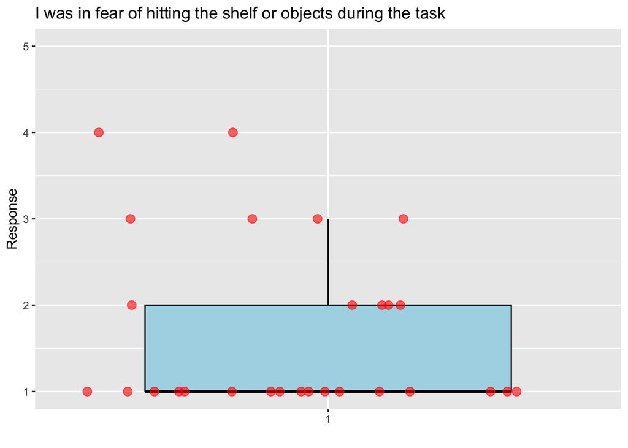

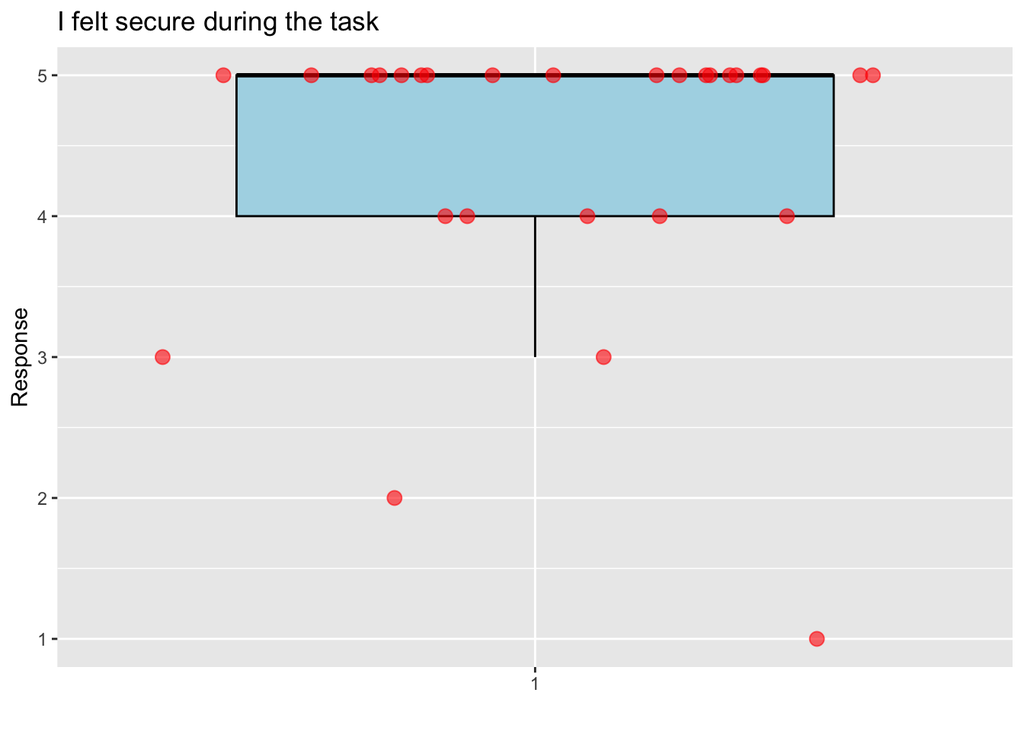

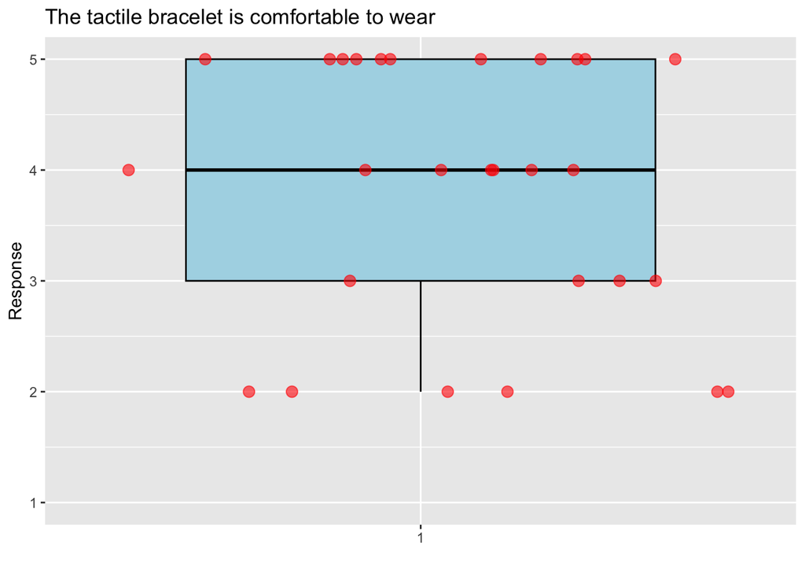

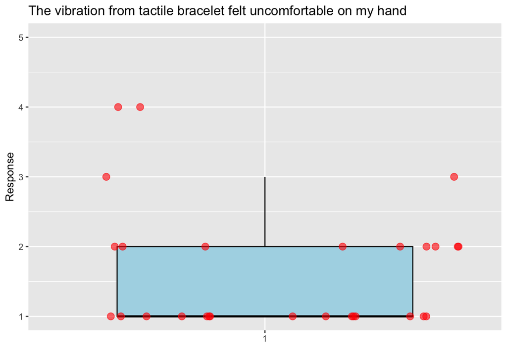

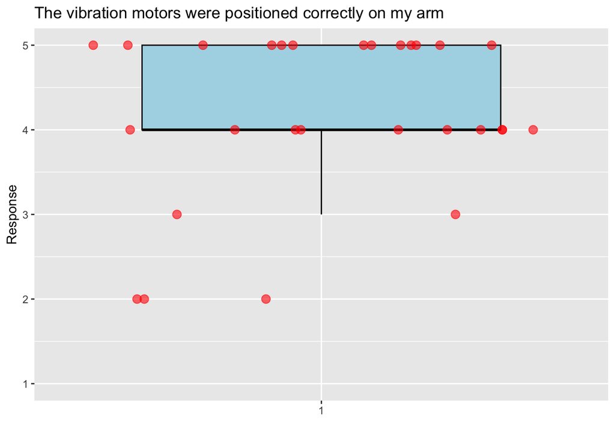

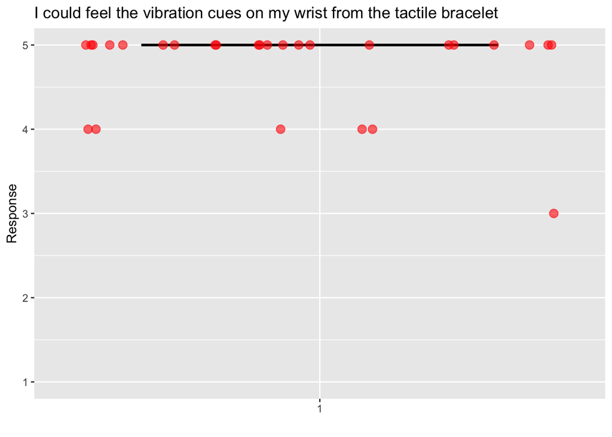

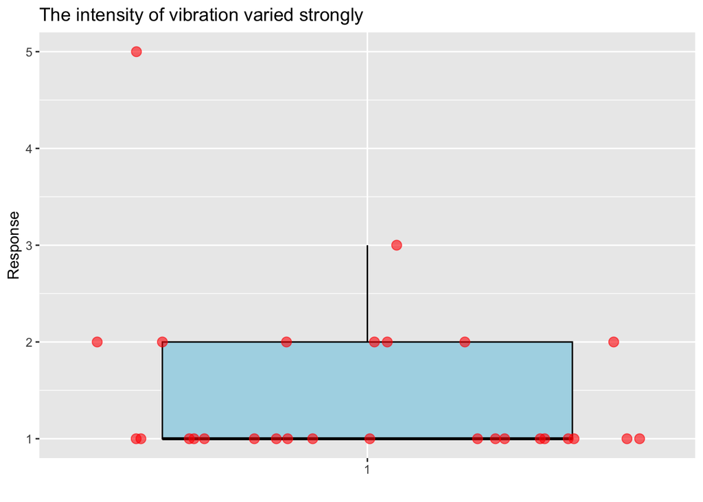

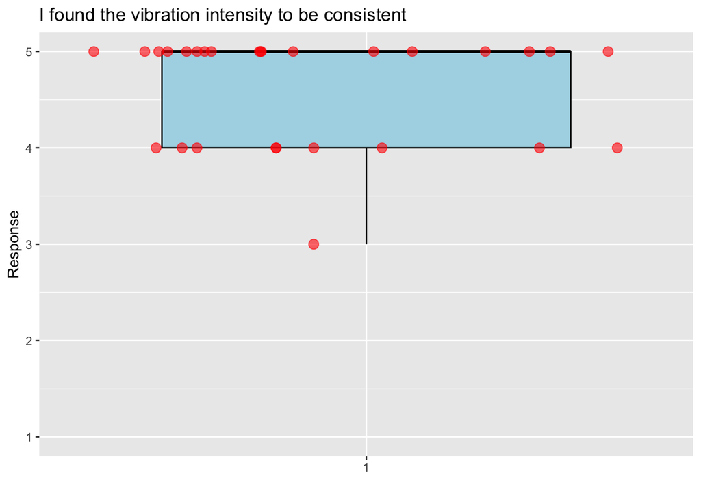

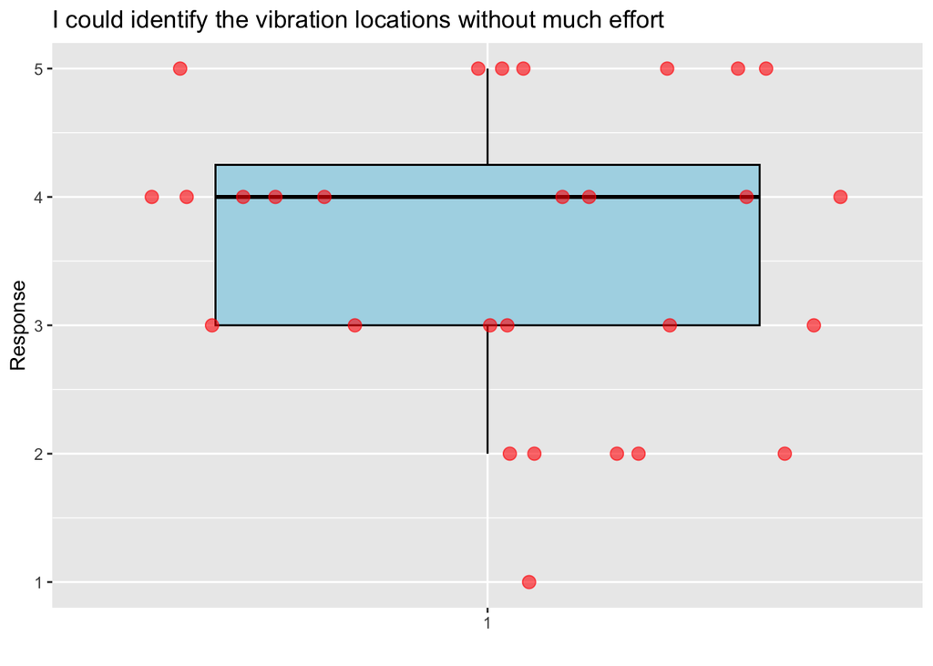

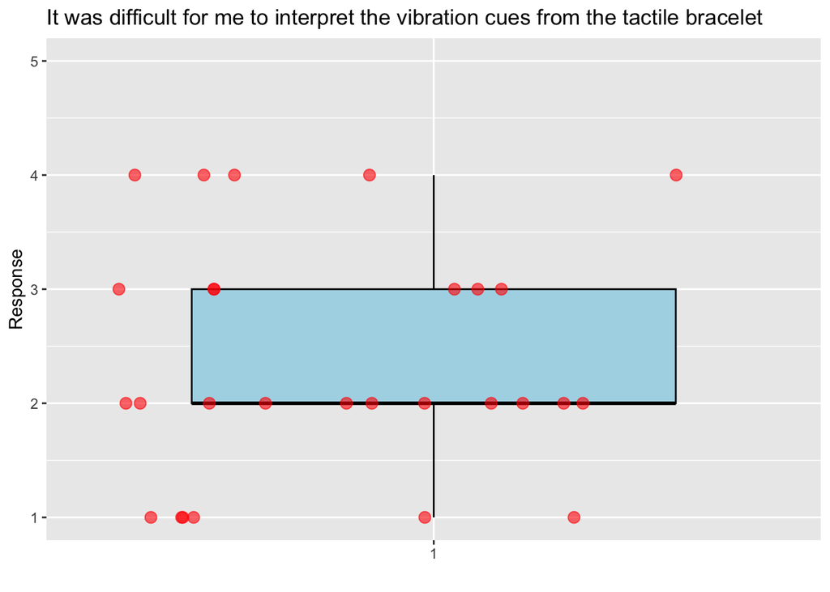

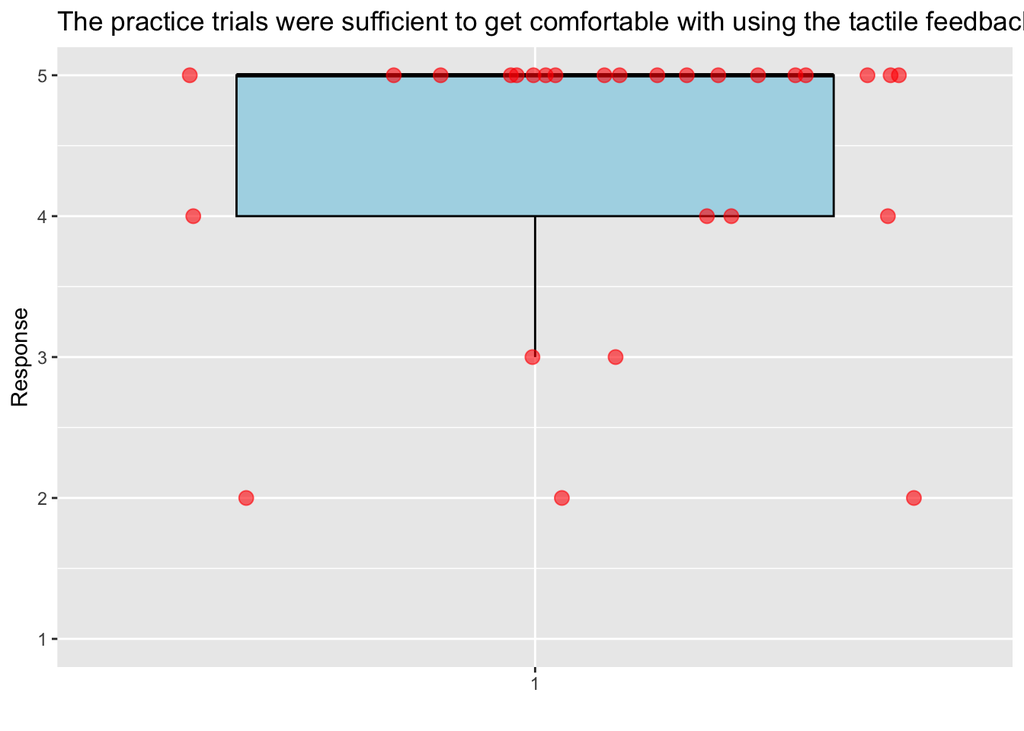

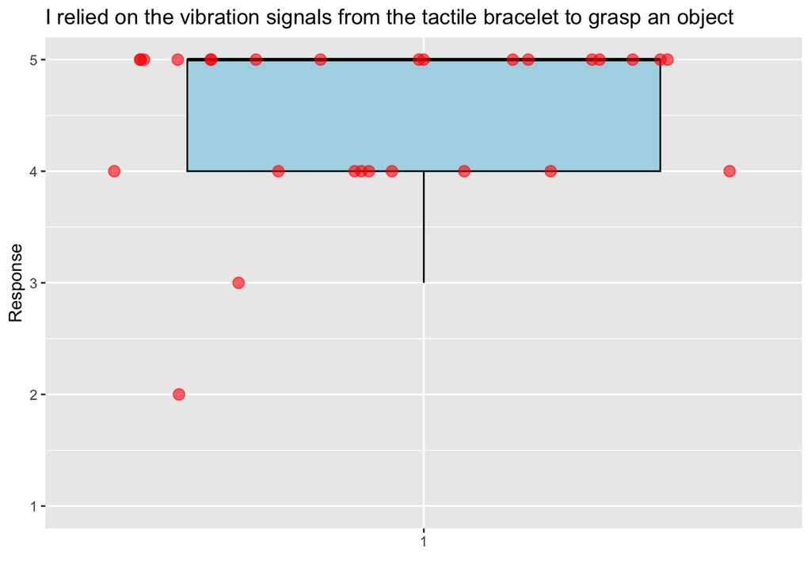

[5 more figures not shown]

```r
# Plot each question with box plot
for (col in colnames(questionnaire_data)[2:18]) {
  plot_data <- data.frame(Response = questionnaire_data[, col], Question = gsub("\\.", " ", col))
  plot_title <- gsub("^X", "", col)
  plot_title <- gsub("\\.", " ", plot_title)

  plot <- ggplot(plot_data, aes(x = factor(1), y = Response)) +
    geom_boxplot(fill = "lightblue", color = "black", outlier.shape = NA) +
    geom_jitter(width = 0.5, height = 0, size = 3, alpha = 0.6, color = "red") +  # add points
    labs(title = plot_title, x = "", y = "Response") +
    #theme(axis.text.x = element_blank(), axis.ticks.x = element_blank()) +
    ylim(1, 5)  # set y-axis limits to 1 and 5

  print(plot)
}
```

# Open-ended questions

We here qualitatively analyse the comments made in the open-ended questions, regarding the experience with the tactile bracelet and the grasping task.

```r
print(questionnaire_data$`Please.describe.your.general.experience.with.the.tactile.bracelet.itself..`)
```

```
##  [1] ""
##  [2] "The tacticle bracelet was easy to wear , after some time it became abit uncomfrotable maybe with the moving alot as well , however it was not that bad. It took me some time to get used to the vibration but I think that once you get used to them they are clear for guiding."
##  [3] "The tactile bracelet was comfortable, I fairly quickly got used to it being on my hand and didn't take notice of it outside of when it was vibrating. The location of the vibrations was not always so easy to distinguish. I especially tended to get confused between the right and bottom vibrat…
##  [4] "It felt quite comfortable and was quite easy to follow the vibration instructions. "
##  [5] "It rested comfortably wrapped around my wrist. As soon as I started experience mild fatigue, left and top vibrations started to become perceptually similar. But that perceptual blending got reversed as soon as I noticed that I moved my hand in the wrong direction. \n\n\n"
##  [6] "The bracelet was comfortable to wear and interact with. It actually helped in navigating my hand, so it was rather effective in its functioning. However, at some point, when the focus on the tactile sensations is lost, the vibrations get mixed and blended between each other that made it har…
##  [7] "Very comfortable. The bracelet and the stretchable support felt very stable on my wrist. The size of the vibrotactile units was nice, not too small, not too big, same with the intensity. The wires connecting the bracelet to the device are not noticeable during the task. I forgot about them.…
##  [8] "As my wrist is smaller than the average adult, I feel that the motor on the bracelet is quite large for me. This has led to confusion with some of the vibrating orders. Perhaps the vibration type could be varied to include sharper or more distinct vibrations."
##  [9] ""
## [10] "The vibrations given by the bracelet were helpful for locating the objects. It was quite intuitive to use. I sometimes (tho in respect to all tries rarely) found it hard to distinguish between the top and right vibrator. I needed to focus to \"understand\" the commands of the bracelet howev…
## [11] "The tactile bracelet was good to understand. Only when up-vibrations came I was waiting a bit to notice if it was an up-vibration or and pulse for grasping, as these happened in the same motor."
## [12] "It took a me quite a while to get used to the vibrations and not mix up the directions. Sometimes I would also intuitively grasp the object. The bracelet was very comfortable and easy to work with. When I lost focus it was also harder to follow the instructions because I really had to conce…
## [13] "The bracelet was comfortable to wear, though the part on  the upper arm got pretty heavy over time. As the trials continued it got more difficult to differentiate the direction of the vibration. It was pretty exhausting to continue the task . The vibration was really intense, potentially ov…
## [14] "It was interesting and once you got used to it it got a little more intuitive though it was sometimes hard to make out which electrode vibrated since the vibration intensity was so strong that I could feel it in my whole lower arm. Another problem was that my arm got a little numb after som…
## [15] "The fit was alright. Tough I had to readjust the position. During the task itself I had some struggles correctly interpreting up and down vibrations although I felt them differently.   "
## [16] "as a prototype great, vibrations sometimes where hard to localize when the hand angle changed, but overall easy to sense. I had to translate the felt vibration into language (“up”, “down”, etc) in my mind, which felt a bit less intuitive than just listening to instructions, but I believe wi…
## [17] "First it was unfamiliar to rely on the vibration, but after a short time i got used to the feeling. "
## [18] "It was an interesting new experience using the tactile bracelet. Being guided by vibrations on my arm made navigating blindfolded (way) easier than I expected. The duration of the vibration hinted the distance I had to move well and I never felt lost in the shelf/positioning of my arm durin…
## [19] "I got used to the bracelet very fast, and it was easy to let myself be guided by it. The only negative aspect was that the positioning of the respective vibrators was difficult to optimize, because the left one was too close to the top one at first and then very close to the bottom one. I o…
```

[output cut: 10 more lines]

*Summary:*  
- some participants had troubles to distinguish vibration directions especially after fatigue (-> blending)  
- differences in wrist circumferences can lead to perception of too large/small motors and/or vibration intensity and distinguishing directions can again be influenced by that  
- grasping cue -> some participants started moving up first –> change it to something else (e.g. all motors vibrate, last direction pulses)  
- some participants felt too much vibration intensity -> numbs wrist (and forearm) -> fatigues -> harder to distinguish -> less intuitive  
- one P with troubles distinguishing spoken left-right reported it was easier with the bracelet

```r
print(questionnaire_data$`Please.describe.your.general.experience.with.the.grasping.task`)
```

```
##  [1] ""
##  [2] "It was fun task, but navigating the shelf at the start was bit hard since I have not seen any of its aspects. however after sometime i could navigate better and anticipate what fruit I will be grasping if for example I went down in the shelf then to  the left. Overall I felt comfortable and…
##  [3] "The task itself was simple to follow. This is especially true of the verbal instruction condition. Sometimes it was easy to get lost in thought in between cues."
##  [4] "Sometimes I was anticipating the “grasp” command as it became sort of a pattern, e.g. left-right-grasp. Maybe more random movements would add the “surprise” effect. "
##  [5] "I would find it more convenient if the bracelet started to pulse-vibrate as soon as my hand is right above the object that I need to grasp. There was a bit of uncertainty as to the distance of the object from my hand as soon as I was instructed to grasp.\n\nSomething like fine or course vib…
##  [6] "The task itself was easy to understand and perform. The instructions were explained to me in a good manner, so I had a nice experience of participating in the experiment. One of the notable struggles that I experienced during the task was the involuntary moving of objects due to their light…
##  [7] "I loved the task. I loved it because of the amount of attention required to postulate my best performance. It was simple methodologically but required a constant level of attention on the stimulation and the sensory channel selected. It has been a very intriguing experience because vision d…
##  [8] "I'm not sure if it's intentional, but as I continued to do the tasks, I became accustomed to the spatial location of the fruits, and began moving my hand with more impulsive movements"
##  [9] ""
## [10] "It was not hard or straining and honestly a bit fun. "
## [11] ""
## [12] "Some objects were harder to grasp than others and I immediately forgot which object was in which position, so  I was always surprised when grasping an object. The Vibrations for the grasping motion were very clear, however sometimes I accidentally automatially grasped the object."
## [13] "I felt mostly confident during the task. The objects were mostly easy to grasp. But the grapes felt like the odd one out."
## [14] "It was alright and I was able to get familiar which the setup pretty quickly. "
## [15] ""
## [16] "took a while to get used to, but then easily understood and doable. I actually started seeing the shelf in front of me, even though my eyes were closed, and remembered where which fruit was an which were a bit harder to grasp."
## [17] "It was fun and a new experience to only rely on one sense. I was surprised how well i could find back to the referencepoint. "
## [18] "During the grasping task, I could really feel the difference between feeling the vibration as an indication or being told in which direction I should move. Eventhough I normally don´t have a problem determining right and left, it was at the first second harder to decide the direction. This …
## [19] "In the beginning, it became clear pretty fast that once a movement up or down was required, the only thing left to do was grasping the object, so at first I started anticipating the grasping. Once I was told not to do so, it was easy to relax and wait for the instructions.\nIt was interesti…
## [20] "It was ok, but maybe it would be necessary to give the instructions a bit slower, because at the begining was hard to completely understand what I needed to do, because I though I had understood the instructions, but when we did the trial I realized that I didn't  really understand what I n…
## [21] "It was in general an easy and fun task. The only comment I'd have is that some objects were harder to grasp that others and that difficult Ed or at least slightly affected my \"reaching\" behavior "
## [22] "When I was instructed to the set up (blind already) and shown the three shelves, I actively thought about how to relate their position to my body so I could find them again without help (upper shelf  - my forehead; middle shelf - chest; lower shelf - knee). For the left/right dimension, it …
## [23] "Doing the task but also trying to be as fast as possible while also moving the camera to the right position, while also moving my hand along the shelf in a continuous motion instead of just immediately skipping to the fruit positions and not anticipating the grasping, was a lot to keep in m…
## [24] "I definitely got more used to the motor sequence, of reaching for each object and returning to the starting spot, towards the end. But I was not anticipating the grasping movement or where we were likely to go next. I let the signal guide me. Of course when moving faster I felt less confide…
## [25] "I think:\n\n - reference point is very important in this case because we can easily lose the objects’ location by losing the reference point. \n\n - as there is no clear sign for front and back, participants must intuitively adjust the front and back distance.\n\n - trust in the system is a…
## [26] "Very interesting to see how you can actually get used to receiving and understanding the information from the bracelet and turning it into a \"command\" for hand movements"
## [27] "The task was logical & simple which helped especially when you have a vibrating device on your arms that feels very different"
## [28] "war leicht. nicht 3 sondern 4 früchte nebeneinander -> vielleicht für später"
## [29] ""
```

**Summary:**  
- grasping anticipation because of regular pattern  
- one P suggests varying vibration intensity based off of distance to target (depth)  
- unnatural head movements during the task needed some attention (because of narrow camera angle)  
- participants easily developed a spatial mapping of the shelf and arrangement of fruits

```r
print(questionnaire_data$`Do.you.have.any.other.comments.for.us.`)
```

```
##  [1] ""
##  [2] ""
##  [3] "No"
##  [4] ""
##  [5] "Awesome work"
##  [6] ""
##  [7] "Great job with the implementation of the wrist band and nice experiment! "
##  [8] "The enjoyable tactile sensation of the fruits made the experiment quite exciting. I am not sure of the exact experimental conditions, perhaps incorporating more complex combinations of instructions involving more than two movements (such as right-left-down) could make the experiment even mo…
##  [9] ""
## [10] "Really nice experiment leaders :))"
## [11] ""
## [12] ""
## [13] ""
## [14] ""
## [15] ""
## [16] "Thanks for the experience and the nice talk <3"
## [17] "\"Mainly my intuition guided my hand movement during the task.\" instead of being guided by the bracelette? Didn't understand this question, sorry. "
## [18] "Not more than: I´m super invested to see where this could turn into in the future and I want to thank you that you innovate something like this that could change blind people´s life in general! Good luck for your future!!"
## [19] ""
## [20] ""
## [21] ""
## [22] ""
## [23] ""
## [24] "Thanks"
## [25] "The design of a reliable system is very important because, with the decrease in trust in the system, the stress of users increases when using it. The increase in stress that is associated with the tightening of the muscles reduces the correct detection of the intensity, duration, and direct…
## [26] ""
## [27] ""
## [28] "ansatz ist super, auf einem arm lassen (nicht auf zwei), lokal belassen ist gut. ist auch unauffällig (fällt nicht auf bei uhren etc). Gummizug vs. klettverschluss vs schiebeelement (an zwei parallelen schienen) auf schiene zum verschieben beim armband."
## [29] ""
```

# Questionnaire constructs

We perform latent variable inference via FA and PCA to extract underlying constructs from numerical responses to the questionnaire items.

## Defining intuitive constructs

Depending on the research goals, we are defining the intuitive constructs of the questions for comparison with the analysis results.

1. **Bracelet usability**
- I felt confident using the tactile bracelet to locate and grasp an object.
- I relied on the vibration signals from the tactile bracelet to grasp an object.
- Mainly my intuition guided my hand movement during the task.
- I could identify the vibration locations without much effort.
- It was difficult for me to interpret the vibration cues from the tactile bracelet.
2. **Bracelet design** (Concept & Comfort)
- The tactile bracelet is comfortable to wear.
- The vibration from tactile bracelet felt uncomfortable on my hand.
- I could feel the vibration cues on my wrist from the tactile bracelet.
- The intensity of vibration varied strongly.
- I found the vibration intensity to be consistent.
3. **Experiment design**
- I was in fear of hitting the shelf or objects during the task.
- I felt secure during the task.
- The practice trials were sufficient to get comfortable with using the tactile feedback.
- I was able to develop a spatial understanding of the shelf.
- I waited for instructions before reaching to grasp an object.
- I was anticipating the grasping motion.
- The vibration motors were positioned correctly on my arm.

## Factor Analysis

```r
# remove NAs
data <- na.omit(questionnaire_data[,2:18])
```

Conduct factor analysis to explore the underlying structure of the questionnaire. This will help confirm or refine the identified constructs.

```r
# remove indices
rownames(data) <- NULL

fa_model <- fa(data, nfactors = 3, rotate = "varimax", fm = "pa", max.iter = 1000)
fa_model
```

```
## Factor Analysis using method =  pa
## Call: fa(r = data, nfactors = 3, rotate = "varimax", max.iter = 1000,
##     fm = "pa")
## Standardized loadings (pattern matrix) based upon correlation matrix
##                                                                                           PA1
## I.was.in.fear.of.hitting.the.shelf.or.objects.during.the.task.                           0.25
## I.felt.secure.during.the.task.                                                           0.17
## The.tactile.bracelet.is.comfortable.to.wear.                                             0.10
## The.vibration.from.tactile.bracelet.felt.uncomfortable.on.my.hand.                      -0.08
## The.vibration.motors.were.positioned.correctly.on.my.arm.                                0.23
## I.could.feel.the.vibration.cues.on.my.wrist.from.the.tactile.bracelet.                  -0.11
## The.intensity.of.vibration.varied.strongly.                                             -0.08
## I.found.the.vibration.intensity.to.be.consistent.                                        0.18
## I.could.identify.the.vibration.locations.without.much.effort.                            0.82
## It.was.difficult.for.me.to.interpret.the.vibration.cues.from.the.tactile.bracelet.      -0.88
## The.practice.trials.were.sufficient.to.get.comfortable.with.using.the.tactile.feedback.  0.61
## I.relied.on.the.vibration.signals.from.the.tactile.bracelet.to.grasp.an.object.          0.31
## Mainly.my.intuition.guided.my.hand.movement.during.the.task.                             0.04
## X.I.felt.confident.using.the.tactile.bracelet.to.locate.and.grasp.an.object.             0.64
## I.was.able.to.develop.a.spatial.understanding.of.the.shelf.                             -0.10
## I.waited.for.instructions.before.reaching.to.grasp.an.object.                            0.29
## I.was.anticipating.the.grasping.motion.                                                 -0.32
##                                                                                           PA2
## I.was.in.fear.of.hitting.the.shelf.or.objects.during.the.task.                          -0.29
## I.felt.secure.during.the.task.                                                           0.05
## The.tactile.bracelet.is.comfortable.to.wear.                                             0.90
## The.vibration.from.tactile.bracelet.felt.uncomfortable.on.my.hand.                      -0.76
## The.vibration.motors.were.positioned.correctly.on.my.arm.                                0.27
## I.could.feel.the.vibration.cues.on.my.wrist.from.the.tactile.bracelet.                   0.18
## The.intensity.of.vibration.varied.strongly.                                             -0.37
## I.found.the.vibration.intensity.to.be.consistent.                                        0.50
## I.could.identify.the.vibration.locations.without.much.effort.                           -0.09
## It.was.difficult.for.me.to.interpret.the.vibration.cues.from.the.tactile.bracelet.      -0.05
## The.practice.trials.were.sufficient.to.get.comfortable.with.using.the.tactile.feedback.  0.15
## I.relied.on.the.vibration.signals.from.the.tactile.bracelet.to.grasp.an.object.          0.37
## Mainly.my.intuition.guided.my.hand.movement.during.the.task.                            -0.05
## X.I.felt.confident.using.the.tactile.bracelet.to.locate.and.grasp.an.object.             0.35
## I.was.able.to.develop.a.spatial.understanding.of.the.shelf.                             -0.03
## I.waited.for.instructions.before.reaching.to.grasp.an.object.                            0.25
## I.was.anticipating.the.grasping.motion.                                                  0.01
```

[output cut: 86 more lines]

```
## The root mean square of the residuals (RMSR) is  0.11
## The df corrected root mean square of the residuals is  0.14
##
## The harmonic n.obs is  28 with the empirical chi square  93.88  with prob <  0.31
## The total n.obs was  28  with Likelihood Chi Square =  117.44  with prob <  0.02
##
## Tucker Lewis Index of factoring reliability =  0.301
## RMSEA index =  0.103  and the 90 % confidence intervals are  0.047 0.161
## BIC =  -175.79
## Fit based upon off diagonal values = 0.79
## Measures of factor score adequacy
##                                                    PA1  PA2  PA3
## Correlation of (regression) scores with factors   0.95 1.00 0.90
## Multiple R square of scores with factors          0.91 1.00 0.81
## Minimum correlation of possible factor scores     0.82 0.99 0.62
```

*Interpretation:* We choose to select the questions of each factor with correlation equal or above 0.2 (at least slight positive correlation) and therefore come up with the following groupings:

**PA2: comfort**  
- The.tactile.bracelet.is.comfortable.to.wear. 0.90  
- I.found.the.vibration.intensity.to.be.consistent. 0.50  
- I.relied.on.the.vibration.signals.from.the.tactile.bracelet.to.grasp.an.object. 0.37  
- X.I.felt.confident.using.the.tactile.bracelet.to.locate.and.grasp.an.object. 0.35  
- The.vibration.motors.were.positioned.correctly.on.my.arm. 0.27  
- I.waited.for.instructions.before.reaching.to.grasp.an.object. 0.25

**PA3: learning / intuition**  
- Mainly.my.intuition.guided.my.hand.movement.during.the.task. 0.74  
- I.was.able.to.develop.a.spatial.understanding.of.the.shelf. 0.74  
- I.was.anticipating.the.grasping.motion. 0.30  
- I.was.in.fear.of.hitting.the.shelf.or.objects.during.the.task. 0.21  
- I.felt.secure.during.the.task. 0.20

## Principal Component Analysis

We perform PCA (dimensionality reduction) to extract the PCs that explain more than half the variance in the data, possible more.

```r
# function for displaying each PC and its ordered correlation coefficients
# returns the correlation matrices after PCA and reconstructed
extract_PC <- function(data, n_comps, thres=-1){
  # normalize data and perform PCA
  corr_matrix <- cor(scale(data))
  data.pca <- princomp(corr_matrix)
  print(summary(data.pca))
  # extract correlation loadings
  loadings <- data.pca$loadings[, 0:n_comps]

  # output each PC
  for (i in 1:n_comps) {
    print(data.frame(item=loadings[,0], PC=loadings[,i]) %>% arrange(desc(PC)) %>% filter(PC >= thres))
  }

  # use different PCA method for data reconstruction
  res <- prcomp(data, scale. = TRUE)
  corr_matrix_reconstructed <- cor(res$x[, 0:n_comps] %*% t(res$rotation[, 0:n_comps]))

  return(list("pca" = res, "loadings" = loadings, "normal" = corr_matrix, "reconstructed" = corr_matrix_reconstructed))
}

# extract 3 PCs
res <- extract_PC(data, 3)
```

```
## Importance of components:
##                           Comp.1    Comp.2    Comp.3     Comp.4     Comp.5
## Standard deviation     0.8530053 0.5472489 0.4850658 0.41773511 0.33597323
## Proportion of Variance 0.4028554 0.1658118 0.1302708 0.09661569 0.06249641
## Cumulative Proportion  0.4028554 0.5686672 0.6989380 0.79555371 0.85805012
##                            Comp.6     Comp.7     Comp.8     Comp.9     Comp.10
## Standard deviation     0.29840242 0.26624325 0.19402404 0.15772818 0.127277428
## Proportion of Variance 0.04930039 0.03924668 0.02084284 0.01377413 0.008969092
## Cumulative Proportion  0.90735051 0.94659719 0.96744002 0.98121416 0.990183249
##                            Comp.11     Comp.12     Comp.13      Comp.14
## Standard deviation     0.093026327 0.071787012 0.044070948 0.0330795902
## Proportion of Variance 0.004791345 0.002853234 0.001075352 0.0006058512
## Cumulative Proportion  0.994974594 0.997827829 0.998903180 0.9995090316
##                             Comp.15      Comp.16      Comp.17
## Standard deviation     0.0280499033 9.998322e-03 7.276234e-09
## Proportion of Variance 0.0004356206 5.534774e-05 2.931292e-17
## Cumulative Proportion  0.9999446523 1.000000e+00 1.000000e+00
##                                                                                                   PC
## It.was.difficult.for.me.to.interpret.the.vibration.cues.from.the.tactile.bracelet.       0.375967871
## The.vibration.from.tactile.bracelet.felt.uncomfortable.on.my.hand.                       0.300459361
## I.was.anticipating.the.grasping.motion.                                                  0.206256958
## The.intensity.of.vibration.varied.strongly.                                              0.156599294
## I.was.able.to.develop.a.spatial.understanding.of.the.shelf.                              0.099180133
## Mainly.my.intuition.guided.my.hand.movement.during.the.task.                             0.040860404
## I.could.feel.the.vibration.cues.on.my.wrist.from.the.tactile.bracelet.                   0.024596184
## I.was.in.fear.of.hitting.the.shelf.or.objects.during.the.task.                           0.005783302
## I.felt.secure.during.the.task.                                                          -0.066551560
## The.vibration.motors.were.positioned.correctly.on.my.arm.                               -0.207696477
## I.waited.for.instructions.before.reaching.to.grasp.an.object.                           -0.258551588
## I.found.the.vibration.intensity.to.be.consistent.                                       -0.268188527
## I.relied.on.the.vibration.signals.from.the.tactile.bracelet.to.grasp.an.object.         -0.295964998
## I.could.identify.the.vibration.locations.without.much.effort.                           -0.297870013
## The.practice.trials.were.sufficient.to.get.comfortable.with.using.the.tactile.feedback. -0.301581712
## The.tactile.bracelet.is.comfortable.to.wear.                                            -0.311940148
## X.I.felt.confident.using.the.tactile.bracelet.to.locate.and.grasp.an.object.            -0.371808303
##                                                                                                  PC
## The.vibration.from.tactile.bracelet.felt.uncomfortable.on.my.hand.                       0.36371516
## The.intensity.of.vibration.varied.strongly.                                              0.34085796
## I.could.identify.the.vibration.locations.without.much.effort.                            0.29493942
## I.was.in.fear.of.hitting.the.shelf.or.objects.during.the.task.                           0.27848321
```

[output cut: 16 more lines]

```
## I.was.in.fear.of.hitting.the.shelf.or.objects.during.the.task.                           0.37220932
## I.could.identify.the.vibration.locations.without.much.effort.                            0.28900607
## The.practice.trials.were.sufficient.to.get.comfortable.with.using.the.tactile.feedback.  0.16286288
## I.felt.secure.during.the.task.                                                           0.14393529
## I.was.anticipating.the.grasping.motion.                                                  0.06845565
## The.vibration.from.tactile.bracelet.felt.uncomfortable.on.my.hand.                       0.06465125
## X.I.felt.confident.using.the.tactile.bracelet.to.locate.and.grasp.an.object.             0.04650658
## The.tactile.bracelet.is.comfortable.to.wear.                                            -0.06137651
## It.was.difficult.for.me.to.interpret.the.vibration.cues.from.the.tactile.bracelet.      -0.07300615
## I.found.the.vibration.intensity.to.be.consistent.                                       -0.09319843
## The.vibration.motors.were.positioned.correctly.on.my.arm.                               -0.10583295
## I.waited.for.instructions.before.reaching.to.grasp.an.object.                           -0.10684810
## I.could.feel.the.vibration.cues.on.my.wrist.from.the.tactile.bracelet.                  -0.13796061
## I.relied.on.the.vibration.signals.from.the.tactile.bracelet.to.grasp.an.object.         -0.14880593
## The.intensity.of.vibration.varied.strongly.                                             -0.32291457
```

```r
eigenvalues <- res$pca$sdev^2
#retained_components <- sum(eigenvalues > 1)
eigenvalues
```

```
##  [1] 3.74424094 2.29056748 2.11265916 1.74392591 1.38995099 1.28989996
##  [7] 1.10051290 0.80034504 0.68819299 0.53996881 0.38446326 0.31255473
## [13] 0.19121521 0.15261372 0.12360567 0.11466227 0.02062095
```

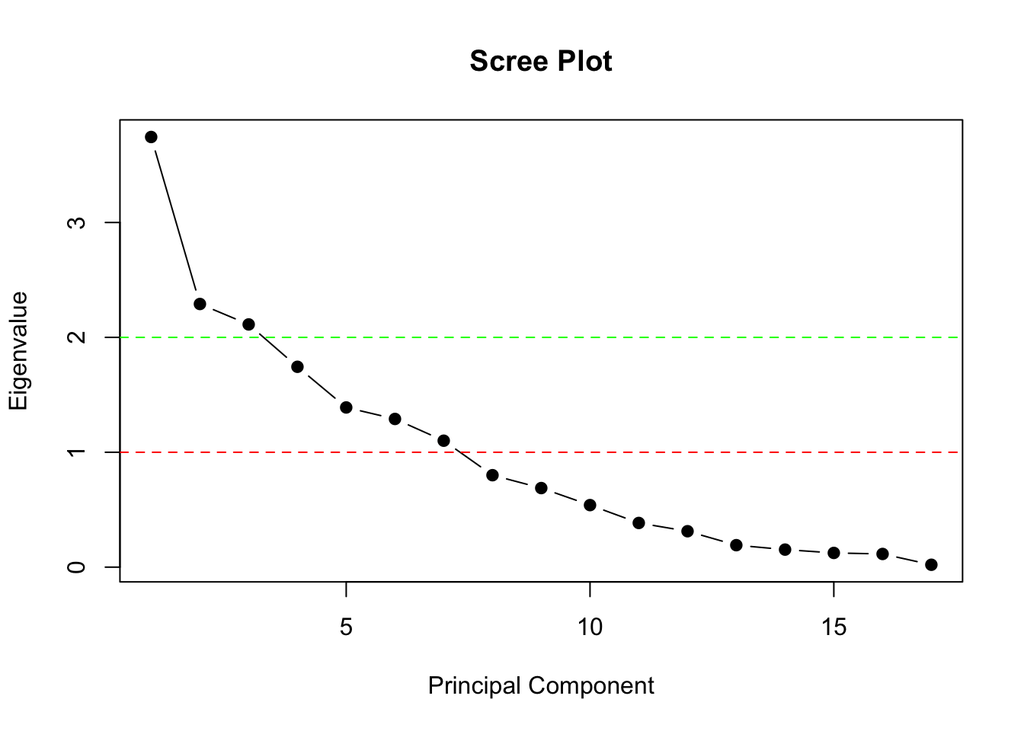

```r
plot(eigenvalues, type = "b", pch = 19, xlab = "Principal Component", ylab = "Eigenvalue", main = "Scree Plot")
abline(h = 1, col = "red", lty = 2)
abline(h = 2, col = "green", lty = 2)
```

```r
print(paste0("Number of PCs with EV > 1: ", sum(eigenvalues > 1)))
```

```
## [1] "Number of PCs with EV > 1: 7"
```

```r
print(paste0("Number of PCs with EV > 2: ", sum(eigenvalues > 2)))
```

```
## [1] "Number of PCs with EV > 2: 3"
```

In this case, 2 PCs explain ~57%, 3 PCs ~70% of the variance in the data. The screeplot shows cut-off lines for eigenvalues > 1 and 2, following Kaiser’s stopping rule. 7 PCs lie above Kaiser’s EV of 1, explaining ~95% of the variance. We here choose 3 PCs, as these are the ones above EV of 2, and it lines up with our a priori selection for the questionnaire design. This indicates that the questions were not formulated in a way such that a single question exclusively investigates one of the intuitive groupings but as 3 PCs explain more than 70% of cumulative variance and afterwards explained-variance differences are lower than 10%, we confidently stick to 3 PCs.

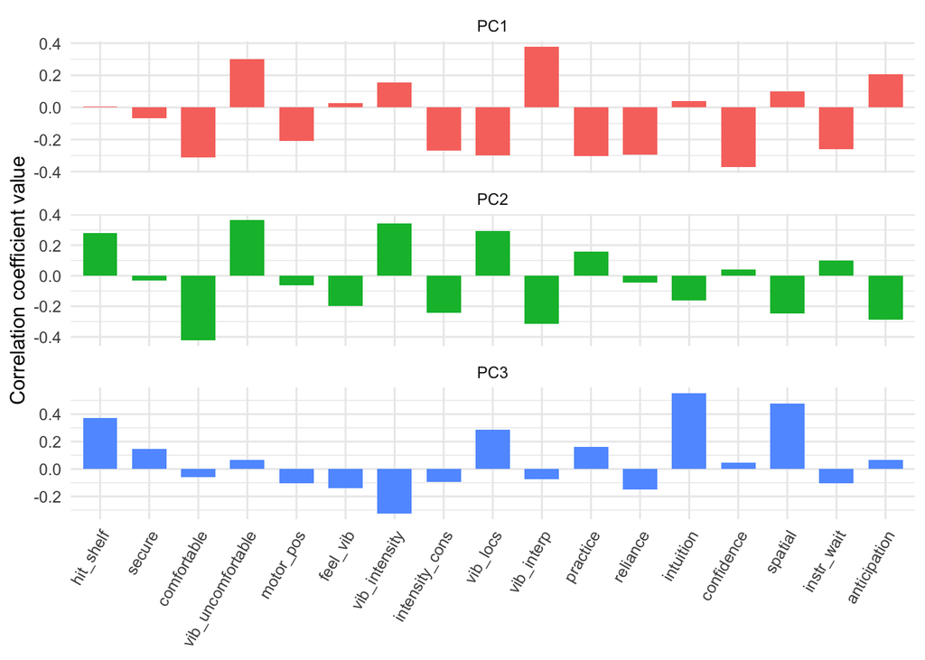

```r
# shorten question names
qs <- c("hit_shelf", "secure", "comfortable", "vib_uncomfortable", "motor_pos", "feel_vib", "vib_intensity", "intensity_cons", "vib_locs", "vib_interp", "practice", "reliance", "intuition", "confidence", "spatial", "instr_wait", "anticipation")

#qs <- c("fear_of_hitting_shelf", "sense_of_task_security", "bracelet_comfort", "vibration_discomfort", "correct_motor_positioning", "ability_to_feel_vibration", "vibration_intensity_variance", "vibration_intensity_consistency", "vibration_location_identifiability", "vibration_interpretability", "practice_sufficiency", "reliance_on_vibrations", "guidance_by_intuition", "bracelet_usage_confidence", "development_of_spatial_map", "instruction_patience", "grasping_anticipation")

pcs <- data.frame(Question = rownames(res$loadings), PC1=res$loadings[,1], PC2=res$loadings[,2], PC3=res$loadings[,3])
# convert to long format
pcs <- pcs %>% pivot_longer(cols = starts_with("PC"), names_to = "PC", values_to = "Value")
pcs$Question <- factor(pcs$Question, levels = rownames(res$loadings))

# Create a faceted barplot
loads <- ggplot(pcs, aes(x = Question, y = Value, fill = PC)) +
  geom_bar(stat = "identity", width = 0.7) +
  labs(#title = "Component loadings of first 3 PCs",
       x = NULL,
       y = "Correlation coefficient value") +
  facet_wrap(~ PC, scales = "free_y", ncol = 1) +
  theme_minimal() +
  theme(legend.position = "none", axis.text.x = element_text(angle = 60, hjust = 1)) +
  scale_x_discrete(labels = qs)
loads
```

```r
#ggsave(paste0(SAVE,"comp_loadings.jpeg"), plot = loads, dpi = 600)
```

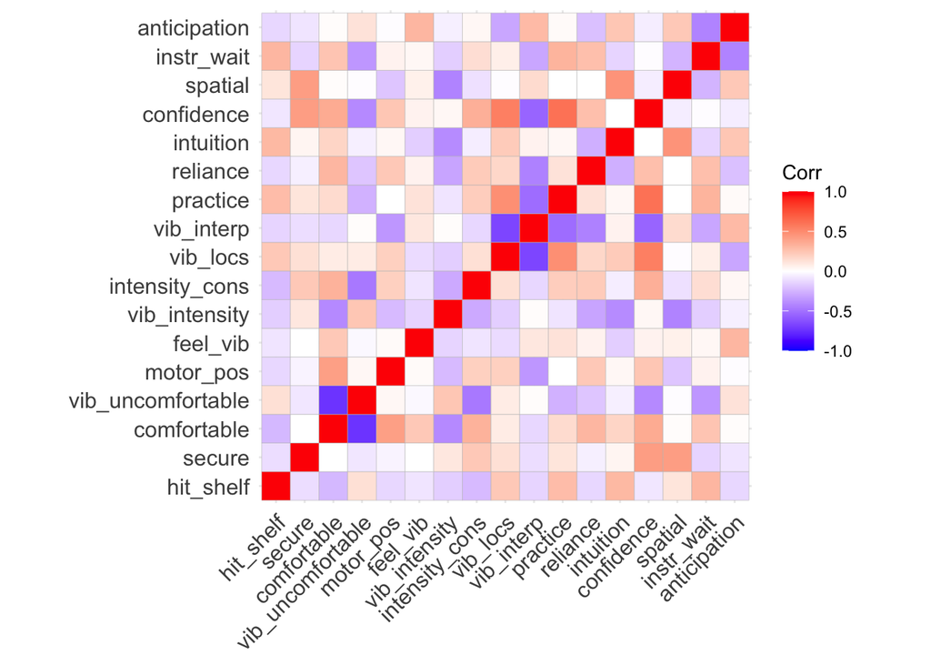

```r
# comfortable, intensity_cons, feel_vib, motor_pos, reliance, confidence, instr_wait

# plot corr matrix after pca
pca_before <- ggcorrplot(res$normal) +
  scale_x_discrete(labels = qs) +
  scale_y_discrete(labels = qs)
pca_before
```

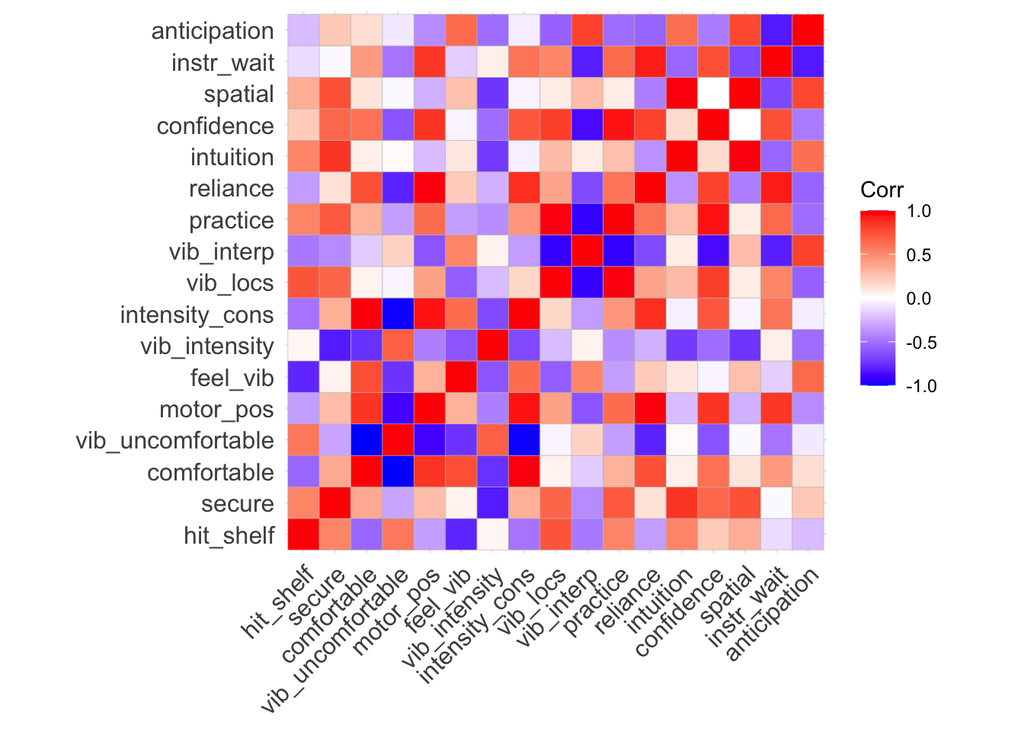

```r
# plot reconstructed corr matrix
pca_after <- ggcorrplot(res$reconstructed) +
  scale_x_discrete(labels = qs) +
  scale_y_discrete(labels = qs)
pca_after
```

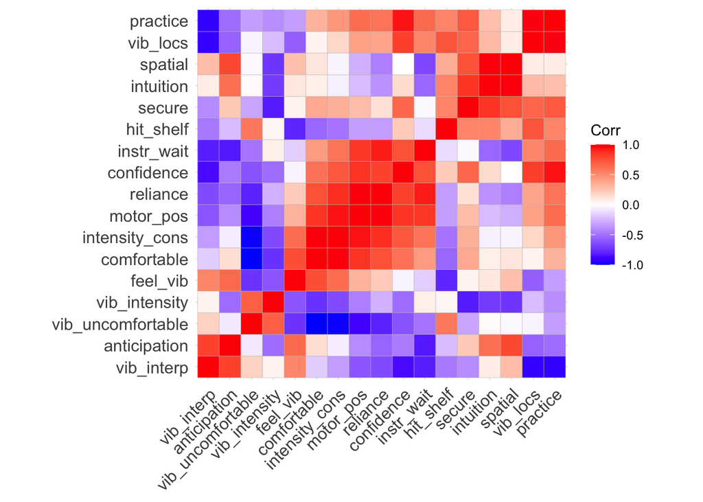

```r
# Perform hierarchical clustering and get order
#hclust_result <- hclust(dist(res$reconstructed))
#order <- hclust_result$order
order <- c(10,17,4,7,6,3,8,5,12,14,16,1,2,13,15,9,11) # re-order to visualize the 3 PCs
corr_reordered <- res$reconstructed[order,order]

# plot re-ordered reconstructed corr matrix
reordered <- ggcorrplot(corr_reordered) +
  scale_x_discrete(labels = qs[order]) +
  scale_y_discrete(labels = qs[order])
reordered
```

```r
#ggsave(paste0(SAVE,"corr_mat_reordered.jpeg"), plot = reordered, dpi = 600)
```

### Interpretation

**Question keys**  
- 1 hit_shelf: I.was.in.fear.of.hitting.the.shelf.or.objects.during.the.task.  
- 2 secure: I.felt.secure.during.the.task.  
- 3 comfortable: The.tactile.bracelet.is.comfortable.to.wear.  
- 4 vib_uncomfortable: The.vibration.from.tactile.bracelet.felt.uncomfortable.on.my.hand.  
- 5 motor_pos: The.vibration.motors.were.positioned.correctly.on.my.arm.  
- 6 feel_vib: I.could.feel.the.vibration.cues.on.my.wrist.from.the.tactile.bracelet.  
- 7 vib_intensity: The.intensity.of.vibration.varied.strongly.  
- 8 intensity_cons: I.found.the.vibration.intensity.to.be.consistent.  
- 9 vib_locs: I.could.identify.the.vibration.locations.without.much.effort.  
- 10 vib_interp: It.was.difficult.for.me.to.interpret.the.vibration.cues.from.the.tactile.bracelet.  
- 11 practice: The.practice.trials.were.sufficient.to.get.comfortable.with.using.the.tactile.feedback.  
- 12 reliance: I.relied.on.the.vibration.signals.from.the.tactile.bracelet.to.grasp.an.object.  
- 13 intuition: Mainly.my.intuition.guided.my.hand.movement.during.the.task.  
- 14 confidence: X.I.felt.confident.using.the.tactile.bracelet.to.locate.and.grasp.an.object.  
- 15 spatial: I.was.able.to.develop.a.spatial.understanding.of.the.shelf.  
- 16 instr_wait: I.waited.for.instructions.before.reaching.to.grasp.an.object.  
- 17 anticipation: I.was.anticipating.the.grasping.motion.

**PC1: bracelet usability**  
- It.was.difficult.for.me.to.interpret.the.vibration.cues.from.the.tactile.bracelet. 0.38 - The.vibration.from.tactile.bracelet.felt.uncomfortable.on.my.hand. 0.30  
- I.was.anticipating.the.grasping.motion. 0.21  
- The.intensity.of.vibration.varied.strongly. 0.16

**PC2: task & bracelet confidence**  
- The.vibration.from.tactile.bracelet.felt.uncomfortable.on.my.hand. 0.36 - The.intensity.of.vibration.varied.strongly. 0.34  
- I.could.identify.the.vibration.locations.without.much.effort. 0.29  
- I.was.in.fear.of.hitting.the.shelf.or.objects.during.the.task. 0.28  
- The.practice.trials.were.sufficient.to.get.comfortable.with.using.the.tactile.feedback. 0.16

**PC3: learning intuition**  
- Mainly.my.intuition.guided.my.hand.movement.during.the.task. 0.55 - I.was.able.to.develop.a.spatial.understanding.of.the.shelf. 0.48  
- I.was.in.fear.of.hitting.the.shelf.or.objects.during.the.task. 0.37  
- I.could.identify.the.vibration.locations.without.much.effort. 0.29  
- The.practice.trials.were.sufficient.to.get.comfortable.with.using.the.tactile.feedback. 0.16  
- I.felt.secure.during.the.task. 0.14

### Visualize PCs

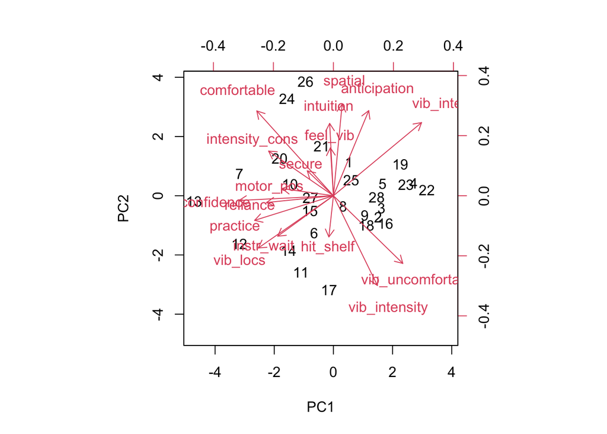

```r
# https://www.statology.org/principal-components-analysis-in-r/

# bi-plot
res$pca$x <- -1*res$pca$x
biplot(res$pca, scale = 0, ylabs = qs) # 1 vs 2
```

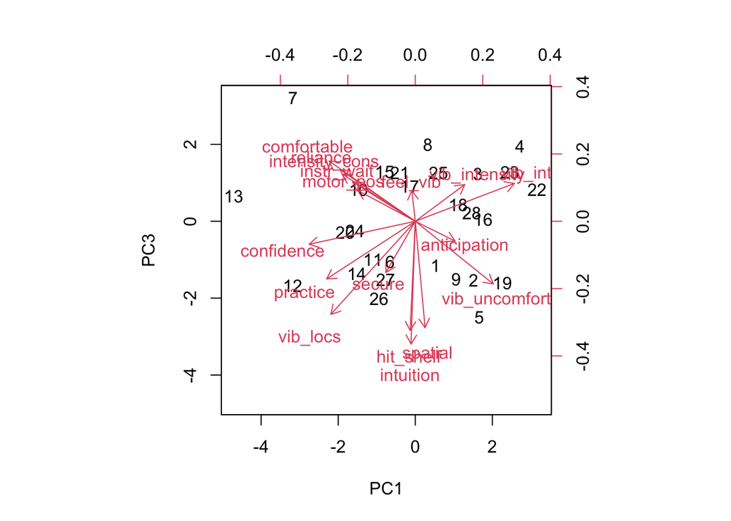

```r
biplot(res$pca, choices = c(1, 3), scale = 0, ylabs=qs) # 1 vs 3
```

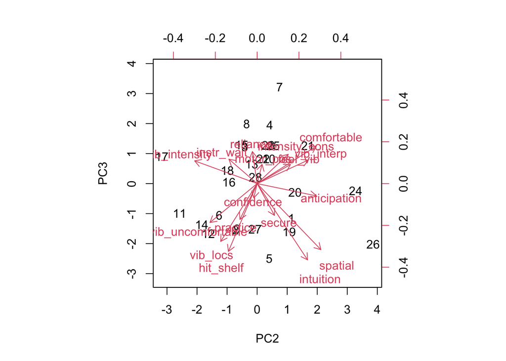

```r
biplot(res$pca, choices = c(2, 3), scale = 0, ylabs=qs) # 2 vs 3
```

# Summary statistics

## Data preparation

We clean the data and wrangle it into another format

```r
clean_data <- data.frame()
for (col in colnames(questionnaire_data)[2:18]) {
  questions <- data.frame(Response = questionnaire_data[, col], Question = gsub("\\.", " ", col))
  title <- gsub("^X", "", col)
  title <- gsub("\\.", " ", title)
  clean_data <- rbind(clean_data, questions[-1,])
}
rownames(clean_data) <- NULL

# rename one question (remove preceding 'X')
clean_data[clean_data$Question == "X I felt confident using the tactile bracelet to locate and grasp an object ",]$Question <- "I felt confident using the tactile bracelet to locate and grasp an object "
```

Add underlying constructs.

```r
coded_data <- clean_data

# PC1: tactile signals, usability, interpretability
usability <- c(
  "The intensity of vibration varied strongly ",
  "The vibration from tactile bracelet felt uncomfortable on my hand ",
  "I was anticipating the grasping motion ",
  "It was difficult for me to interpret the vibration cues from the tactile bracelet "
)

# PC2: experimental design, bracelet design, consistency
task <- c(
  "I could feel the vibration cues on my wrist from the tactile bracelet ",
  "The tactile bracelet is comfortable to wear ",
  "I found the vibration intensity to be consistent ",
  "The vibration motors were positioned correctly on my arm ",
  "I relied on the vibration signals from the tactile bracelet to grasp an object ",
  "I felt confident using the tactile bracelet to locate and grasp an object ",
  "I waited for instructions before reaching to grasp an object "
)

# PC3: security, confidence, practice
confidence <- c(
  "I was in fear of hitting the shelf or objects during the task ",
  "I felt secure during the task ",
  "Mainly my intuition guided my hand movement during the task ",
  "I was able to develop a spatial understanding of the shelf ",
  "I could identify the vibration locations without much effort ",
  "The practice trials were sufficient to get comfortable with using the tactile feedback "
)

coded_data$PC1 <- coded_data$Question %in% usability
coded_data$PC2 <- coded_data$Question %in% task
coded_data$PC3 <- coded_data$Question %in% confidence
```

### Coding direction

```r
conditions <- coded_data$Question %in% c(
  "It was difficult for me to interpret the vibration cues from the tactile bracelet ",
  "The vibration from tactile bracelet felt uncomfortable on my hand ",
  "The intensity of vibration varied strongly ",
  "I was in fear of hitting the shelf or objects during the task ",
  "I was anticipating the grasping motion "
)

# change coding direction
coded_data$Response[conditions] <-
  ifelse(coded_data$Response[conditions] == 1, 5,
         ifelse(coded_data$Response[conditions] == 2, 4,
                ifelse(coded_data$Response[conditions] == 4, 2,
                       ifelse(coded_data$Response[conditions] == 5, 1, 3))))

# rename questions for easier interpretability
coded_data <- coded_data %>%
  mutate(Question = case_when(
    Question == "It was difficult for me to interpret the vibration cues from the tactile bracelet " ~ "It was easy for me to interpret the vibration cues from the tactile bracelet ",
    Question == "The vibration from tactile bracelet felt uncomfortable on my hand " ~ "The vibration from tactile bracelet felt comfortable on my hand ",
    Question == "The intensity of vibration varied strongly " ~ "The intensity of vibration did not vary strongly ",
    Question == "I was in fear of hitting the shelf or objects during the task " ~ "I was not in fear of hitting the shelf or objects during the task ",
    Question == "I was anticipating the grasping motion " ~ "I was not anticipating the grasping motion ",
    TRUE ~ Question
  ))

#coded_data
```

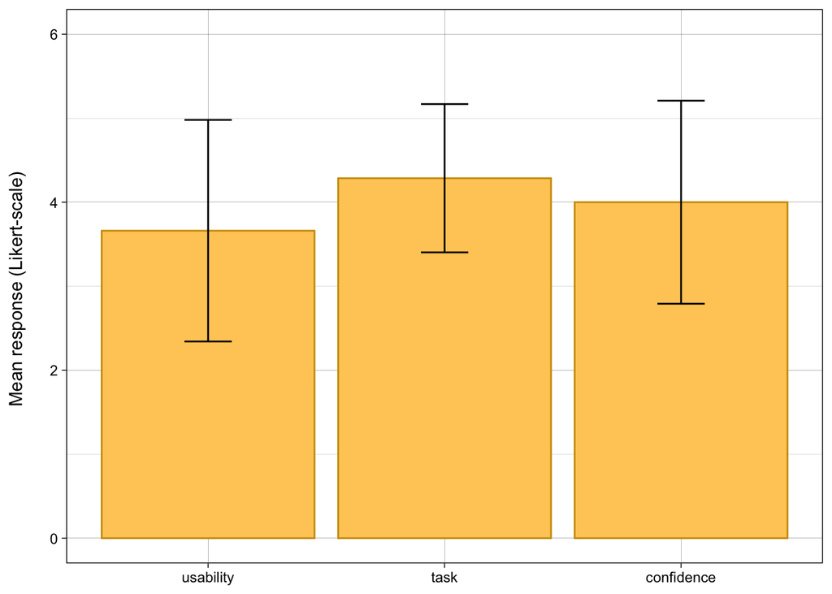

```r
pc1 <- coded_data %>% filter(PC1) %>% summarize(mean = mean(Response), sd=sd(Response))
pc2 <- coded_data %>% filter(PC2) %>% summarize(mean = mean(Response), sd=sd(Response))
pc3 <- coded_data %>% filter(PC3) %>% summarize(mean = mean(Response), sd=sd(Response))

construct_eval <- data.frame(mean=c(pc1[,1],pc2[,1],pc3[,1]), sd=c(pc1[,2],pc2[,2],pc3[,2]), Construct=factor(c("usability", "task", "confidence"), levels = c("usability", "task", "confidence"))) %>%
  ggplot(aes(x=Construct, y = mean)) +
  geom_bar(stat = "identity", position = "dodge", colour="#CC9900", fill="#FFCC66") +
  geom_errorbar(aes(ymin = mean - sd, ymax = mean + sd), width=0.2) +
  #geom_text(aes(label = round(mean, 2)), position = position_dodge(width = 1), vjust = 2, hjust=0.5) +
  labs(
    #title = "Mean participant evaluation per construct",
    x = NULL,
    y = "Mean response (Likert-scale) \n",
    ) +
  theme_linedraw() +
  scale_y_continuous(limits=c(0,6))

construct_eval
```

```r
#ggsave(paste0(SAVE,"construct_eval.jpeg"), plot = construct_eval, dpi = 600)
```

*Interpretation:* Participants rated the usability of the bracelet lowest with a mean of 3.66 (sd = 1.32), most certainly because some participants had a hard time correctly interpreting the vibration signals as motors directly on a bone spread the signal across larger areas. Task design and the usage of the bracelet in the specific task was rated highest with 4.29 (sd = 0.88), indicating a generally good experimental design and adaptation to the bracelet. Confidence of using the bracelet was rated with 4.0 (sd = 1.21) suggesting that the idea of the bracelet and the usage itself are learnable relatively quickly. Overall, participants rated the whole experience relatively high which serves as confirmation for further developing the bracelet.

# References

- Kording, K., Blohm, G., Schrater, P., & Kay, K. (2018). Appreciating diversity of goals in computational neuroscience. OSF Preprints.
- Norman, G. (2010). Likert scales, levels of measurement and the “laws” of statistics. Advances in health sciences education, 15(5), 625-632.
- Sullivan, G. M., & Artino, A. R., Jr (2013). Analyzing and interpreting data from likert-type scales. Journal of graduate medical education, 5(4), 541–542. https://doi.org/10.4300/JGME-5-4-18.
- de Winter, J.C.F., & Dodou, D. (2010), Five-Point Likert Items: t test versus Mann-Whitney-Wilcoxon, Practical Assessment, Research and Evaluation, 15(11).